# Date and Time

## Agenda

- Dates
- Times
- Date-times
- Readings: R4DS Chapters 16

## Dates

```r
library(tidyverse)
library(dslabs)
data("polls_us_election_2016")
polls_us_election_2016 %>% head
##   state  startdate    enddate
## 1  U.S. 2016-11-03 2016-11-06
## 2  U.S. 2016-11-01 2016-11-07
## 3  U.S. 2016-11-02 2016-11-06
## 4  U.S. 2016-11-04 2016-11-07
## 5  U.S. 2016-11-03 2016-11-06
## 6  U.S. 2016-11-03 2016-11-06
##                                                     pollster grade
## 1                                   ABC News/Washington Post    A+
## 2                                    Google Consumer Surveys     B
## 3                                                      Ipsos    A-
## 4                                                     YouGov     B
## 5                                           Gravis Marketing    B-
## 6 Fox News/Anderson Robbins Research/Shaw & Company Research     A
##   samplesize population rawpoll_clinton rawpoll_trump rawpoll_johnson
## 1       2220         lv           47.00         43.00            4.00
## 2      26574         lv           38.03         35.69            5.46
## 3       2195         lv           42.00         39.00            6.00
## 4       3677         lv           45.00         41.00            5.00
## 5      16639         rv           47.00         43.00            3.00
## 6       1295         lv           48.00         44.00            3.00
##   rawpoll_mcmullin adjpoll_clinton adjpoll_trump adjpoll_johnson
## 1               NA        45.20163      41.72430        4.626221
## 2               NA        43.34557      41.21439        5.175792
## 3               NA        42.02638      38.81620        6.844734
## 4               NA        45.65676      40.92004        6.069454
## 5               NA        46.84089      42.33184        3.726098
## 6               NA        49.02208      43.95631        3.057876
##   adjpoll_mcmullin
## 1               NA
## 2               NA
## 3               NA
## 4               NA
## 5               NA
## 6               NA
polls_us_election_2016$startdate %>% head
## [1] "2016-11-03" "2016-11-01" "2016-11-02" "2016-11-04" "2016-11-03"
## [6] "2016-11-03"
```

## Dates

These values are *not* strings, and not numbers!

```r
class(polls_us_election_2016$startdate)
## [1] "Date"
as.numeric(polls_us_election_2016$startdate) %>% head
## [1] 17108 17106 17107 17109 17108 17108
as.Date("1970-01-01") %>% as.numeric
## [1] 0
```

## Dates and times

There are three types of date/time data that refer to an instant in time:

- A date. Tibbles print this as `<date>`.
- A time within a day. Tibbles print this as `<time>`.
- A date-time is a date plus a time: it uniquely identifies an instant in time (typically to the nearest second). Tibbles print this as `<dttm>`

R doesn’t have a native class for storing times. If you need one, you can use the `hms` package

## Dates in other functions

We can exploit the numeric format for positions, but keep the strings for labels:

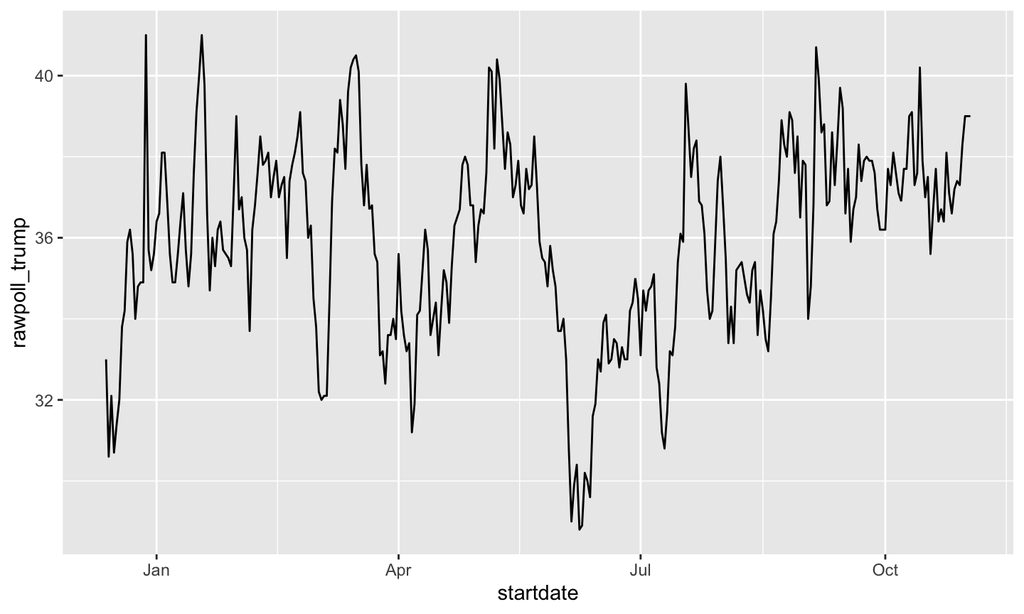

## lubridate

The `tidyverse` includes functionality for dealing with dates through the `lubridate` package.

```r
library(lubridate)
set.seed(2002)
dates <- sample(polls_us_election_2016$startdate, 10) %>% sort
dates
##  [1] "2016-05-31" "2016-08-08" "2016-08-19" "2016-09-22" "2016-09-27"
##  [6] "2016-10-12" "2016-10-24" "2016-10-26" "2016-10-29" "2016-10-30"
```

## lubridate functions

```r
tibble(date = dates,
       month = month(dates),
       day = day(dates),
       year = year(dates))
## # A tibble: 10 x 4
##    date       month   day  year
##    <date>     <dbl> <int> <dbl>
##  1 2016-05-31     5    31  2016
##  2 2016-08-08     8     8  2016
##  3 2016-08-19     8    19  2016
##  4 2016-09-22     9    22  2016
##  5 2016-09-27     9    27  2016
##  6 2016-10-12    10    12  2016
##  7 2016-10-24    10    24  2016
##  8 2016-10-26    10    26  2016
##  9 2016-10-29    10    29  2016
## 10 2016-10-30    10    30  2016
```

## lubridate functions

```r
month(dates, label = TRUE)
##  [1] May Aug Aug Sep Sep Oct Oct Oct Oct Oct
## 12 Levels: Jan < Feb < Mar < Apr < May < Jun < Jul < Aug < Sep < ... < Dec
```

## Dates and times

To get the current date or date-time you can use `today()` or `now()`:

```r
today()
## [1] "2020-02-12"
now()
## [1] "2020-02-12 21:14:41 CST"
```

## Dates and times

There are three ways you’re likely to create a date/time:

- From a string.
- From individual date-time components.
- From an existing date/time object.

## Parsers

`ymd` will try to convert a string to YYYY-MM-DD format:

```r
x <- c(20090101, "2009-01-02", "2009 01 03", "2009-1-4",
       "2009-1, 5", "Created on 2009 1 6", "200901 !!! 07")
ymd(x)
## [1] "2009-01-01" "2009-01-02" "2009-01-03" "2009-01-04" "2009-01-05"
## [6] "2009-01-06" "2009-01-07"
```

## Parsers

What if our date was formatted differently?

```r
x <- "09/01/02"
ymd(x)
## [1] "2009-01-02"
mdy(x)
## [1] "2002-09-01"
ydm(x)
## [1] "2009-02-01"
myd(x)
## [1] "2001-09-02"
dmy(x)
## [1] "2002-01-09"
dym(x)
## [1] "2001-02-09"
```

## Parsers

We can create date-time objects too:

```r
ymd_hms("2017-01-31 20:11:59")
## [1] "2017-01-31 20:11:59 UTC"
mdy_hm("01/31/2017 08:01")
## [1] "2017-01-31 08:01:00 UTC"
ymd(x, tz = "UTC")
## [1] "2009-01-02 UTC"
```

## Combining columns

```r
library(nycflights13)
flights %>% select(year, month, day, hour, minute)
## # A tibble: 336,776 x 5
##     year month   day  hour minute
##    <int> <int> <int> <dbl>  <dbl>
##  1  2013     1     1     5     15
##  2  2013     1     1     5     29
##  3  2013     1     1     5     40
##  4  2013     1     1     5     45
##  5  2013     1     1     6      0
##  6  2013     1     1     5     58
##  7  2013     1     1     6      0
##  8  2013     1     1     6      0
##  9  2013     1     1     6      0
## 10  2013     1     1     6      0
## # … with 336,766 more rows
```

## Combining columns

```r
flights %>%
  select(year, month, day, hour, minute) %>%
  mutate(departure = make_datetime(year, month, day, hour, minute))
## # A tibble: 336,776 x 6
##     year month   day  hour minute departure
##    <int> <int> <int> <dbl>  <dbl> <dttm>
##  1  2013     1     1     5     15 2013-01-01 05:15:00
##  2  2013     1     1     5     29 2013-01-01 05:29:00
##  3  2013     1     1     5     40 2013-01-01 05:40:00
##  4  2013     1     1     5     45 2013-01-01 05:45:00
##  5  2013     1     1     6      0 2013-01-01 06:00:00
##  6  2013     1     1     5     58 2013-01-01 05:58:00
##  7  2013     1     1     6      0 2013-01-01 06:00:00
##  8  2013     1     1     6      0 2013-01-01 06:00:00
##  9  2013     1     1     6      0 2013-01-01 06:00:00
## 10  2013     1     1     6      0 2013-01-01 06:00:00
## # … with 336,766 more rows
```

## Converting columns

```r
flights %>% select(arr_time, dep_time)
## # A tibble: 336,776 x 2
##    arr_time dep_time
##       <int>    <int>
##  1      830      517
##  2      850      533
##  3      923      542
##  4     1004      544
##  5      812      554
##  6      740      554
##  7      913      555
##  8      709      557
##  9      838      557
## 10      753      558
## # … with 336,766 more rows
```

## Converting columns

```r
make_datetime_100 <- function(year, month, day, time) {
  make_datetime(year, month, day, time %/% 100, time %% 100)
}

flights_dt <- flights %>%
  filter(!is.na(dep_time), !is.na(arr_time)) %>%
  mutate(
    dep_time = make_datetime_100(year, month, day, dep_time),
    arr_time = make_datetime_100(year, month, day, arr_time),
    sched_dep_time = make_datetime_100(year, month, day, sched_dep_time),
    sched_arr_time = make_datetime_100(year, month, day, sched_arr_time)
  ) %>%
  select(origin, dest, ends_with("delay"), ends_with("time"))
```

## Converting columns

## Using date-times

Note that when you use date-times in a numeric context (like in a histogram), 1 means 1 second, so a binwidth of 86400 means one day. For dates, 1 means 1 day.

```r
flights_dt %>%
  filter(dep_time < ymd(20130102)) %>%
  ggplot(aes(dep_time)) +
  geom_freqpoly(binwidth = 600) # 600 s = 10 minutes
```

[output not shown]

## Other types

```r
as_datetime(today())
## [1] "2020-02-12 UTC"
as_date(now())
## [1] "2020-02-12"

as_datetime(36000) #Seconds since UNIX Epoch
## [1] "1970-01-01 10:00:00 UTC"
as_date(3650) #Days since UNIX Epoch
## [1] "1979-12-30"
```

## Accessor functions

- `year()`
- `month()` (`label = TRUE` and `abbr = FALSE` options)
- `mday()` (day of the month)
- `yday()` (day of the year)
- `wday()` (day of the week, `label = TRUE` and `abbr = FALSE` options)
- `hour()`
- `minute()`
- `second()`

## Modification functions

For plotting/summarizing, it’s sometimes useful to round the date to a nearby unit of time:

- `floor_date()`
- `round_date()`
- `ceiling_date()`

## Durations

Durations calculated by seconds:

```r
dseconds(15)
## [1] "15s"
dminutes(10)
## [1] "600s (~10 minutes)"
dhours(c(12, 24))
## [1] "43200s (~12 hours)" "86400s (~1 days)"
ddays(0:5)
## [1] "0s"                "86400s (~1 days)"  "172800s (~2 days)"
## [4] "259200s (~3 days)" "345600s (~4 days)" "432000s (~5 days)"
dweeks(3)
## [1] "1814400s (~3 weeks)"
dyears(1)
## [1] "31536000s (~52.14 weeks)"
```

## Duration calculations

```r
2 * dyears(1)
## [1] "63072000s (~2 years)"
dyears(1) + dweeks(12) + dhours(15)
## [1] "38847600s (~1.23 years)"
tomorrow <- today() + ddays(1)
last_year <- today() - dyears(1)
```

## Duration calculations

```r
one_pm <- ymd_hms("2016-03-12 13:00:00", tz = "America/New_York")
one_pm
## [1] "2016-03-12 13:00:00 EST"
one_pm + ddays(1)
## [1] "2016-03-13 14:00:00 EDT"
```

## Periods

More “human-friendly” calculations:

```r
one_pm
## [1] "2016-03-12 13:00:00 EST"
one_pm + days(1)
## [1] "2016-03-13 13:00:00 EDT"
```

## Periods

```r
seconds(15)
## [1] "15S"
minutes(10)
## [1] "10M 0S"
hours(c(12, 24))
## [1] "12H 0M 0S" "24H 0M 0S"
days(7)
## [1] "7d 0H 0M 0S"
months(1:6)
## [1] "1m 0d 0H 0M 0S" "2m 0d 0H 0M 0S" "3m 0d 0H 0M 0S" "4m 0d 0H 0M 0S"
## [5] "5m 0d 0H 0M 0S" "6m 0d 0H 0M 0S"
weeks(3)
## [1] "21d 0H 0M 0S"
years(1)
## [1] "1y 0m 0d 0H 0M 0S"
```

## Flights example

```r
flights_dt %>%
  filter(arr_time < dep_time) %>%
  select(dep_time, arr_time)
## # A tibble: 10,633 x 2
##    dep_time            arr_time
##    <dttm>              <dttm>
##  1 2013-01-01 19:29:00 2013-01-01 00:03:00
##  2 2013-01-01 19:39:00 2013-01-01 00:29:00
##  3 2013-01-01 20:58:00 2013-01-01 00:08:00
##  4 2013-01-01 21:02:00 2013-01-01 01:46:00
##  5 2013-01-01 21:08:00 2013-01-01 00:25:00
##  6 2013-01-01 21:20:00 2013-01-01 00:16:00
##  7 2013-01-01 21:21:00 2013-01-01 00:06:00
##  8 2013-01-01 21:28:00 2013-01-01 00:26:00
##  9 2013-01-01 21:34:00 2013-01-01 00:20:00
## 10 2013-01-01 21:36:00 2013-01-01 00:25:00
## # … with 10,623 more rows
```

## Flights example

```r
flights_dt <- flights_dt %>%
  mutate(
    overnight = arr_time < dep_time,
    arr_time = arr_time + days(overnight * 1),
    sched_arr_time = sched_arr_time + days(overnight * 1)
  )
```

## Intervals

```r
years(1) / days(1)
## [1] 365.25
next_year <- today() + years(1)
(today() %--% next_year) / ddays(1)
## [1] 366
```

## Time zones

See the complete list of all time zone names with `OlsonNames()`:

```r
length(OlsonNames())
## [1] 593
head(OlsonNames())
## [1] "Africa/Abidjan"     "Africa/Accra"       "Africa/Addis_Ababa"
## [4] "Africa/Algiers"     "Africa/Asmara"      "Africa/Asmera"
```